# Polyglot programming for single-cell analysis

Louise Deconinck

Benjamin Rombaut

Robrecht Cannoodt

2024-09-12

# Introduction

1. How do you interact with a package in another language?
2. How do you make you package useable for developers in other languages?

We will be focusing on R & Python

# Summary

**Interoperability** between languages allows analysts to take advantage of the strengths of different ecosystems

**On-disk** interoperability uses standard file formats to transfer data and is typically more reliable

**In-memory** interoperability transfers data directly between parallel sessions and is convenient for interactive analysis

While interoperability is currently possible developers continue to improve the experience

[Single-cell best practices: Interoperability](https://www.sc-best-practices.org/introduction/interoperability.html)

# How do you interact with a package in another language?

1. In-memory interoperability
2. Disk-based interoperability

# How do you make your package useable for developers in other languages?

1. Package-based interoperability
2. Best practices

## Package-based interoperability

or: the question of reimplementation.

- Consider the pros:
  1. Discoverability
  2. Can your package be useful in other domains?
  3. Very user friendly
- Consider the cons:
  1. Think twice: is it worth it?
  2. **It’s a lot of work**
  3. How will you keep it up to date?
  4. How will you ensure parity?

## Package-based interoperability

Please learn both R & Python

## Best practices

1. Work with the standards
2. Work with matrices, arrays and dataframes
3. Provide vignettes on interoperability

# In-memory interoperability

[figure not shown]

## Overview

1. Advantages & disadvantages
2. Pitfalls when using Python & R
3. Rpy2
4. Reticulate

## in-memory interoperability advantages and disadvantages

- advantages
  - no need to write & read results
  - useful when you need a limited amount of functions in another language
- disadvantages
  - not always access to all classes
  - data duplication
  - you need to manage the environments

## Pitfalls when using Python and R

### Column major vs row major matrices

In R: every dense matrix is stored as column major

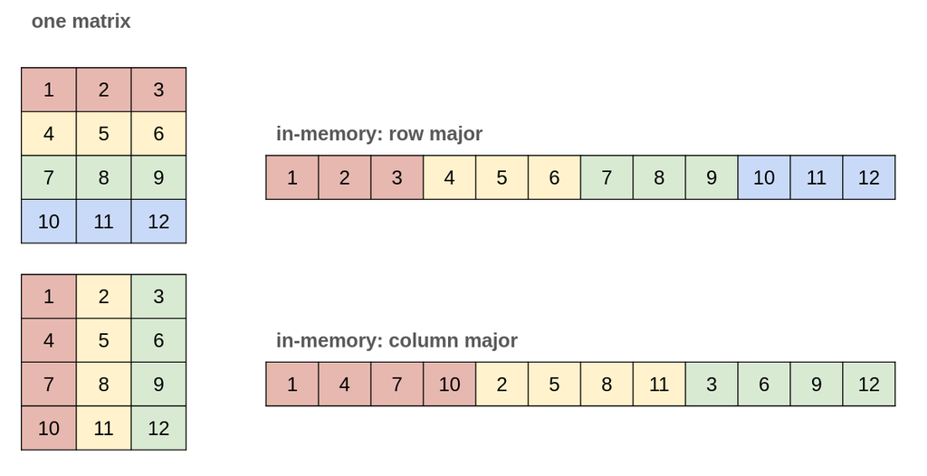

### Indexing

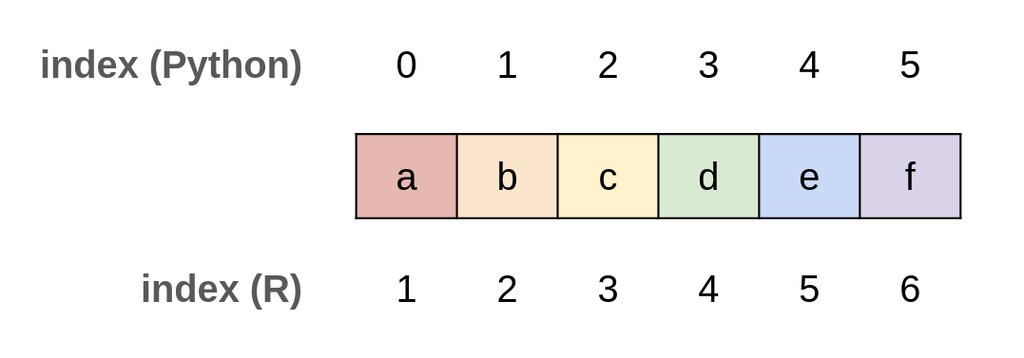

### Dots and underscores

- mapping in rpy2

```python
from rpy2.robjects.packages import importr

d = {'package.dependencies': 'package_dot_dependencies',
     'package_dependencies': 'package_uscore_dependencies'}
tools = importr('tools', robject_translations = d)
```

### Integers

```r
library(reticulate)
bi <- reticulate::import_builtins()

bi$list(bi$range(0, 5))
# TypeError: 'float' object cannot be interpreted as an integer
```

```r
library(reticulate)
bi <- reticulate::import_builtins()

bi$list(bi$range(0L, 5L))
# [1] 0 1 2 3 4
```

## Rpy2

- Accessing R from Python
  - `rpy2.rinterface`, the low-level interface
  - `rpy2.robjects`, the high-level interface

```python
import rpy2
import rpy2.robjects as robjects

vector = robjects.IntVector([1,2,3])
rsum = robjects.r['sum']

rsum(vector)
```

IntVector with 1 elements.

| 6 |
| --- |

### Rpy2: basics

```python
str_vector = robjects.StrVector(['abc', 'def', 'ghi'])
flt_vector = robjects.FloatVector([0.3, 0.8, 0.7])
int_vector = robjects.IntVector([1, 2, 3])
mtx = robjects.r.matrix(robjects.IntVector(range(10)), nrow=5)
print(mtx)
```

```
     [,1] [,2]
[1,]    0    5
[2,]    1    6
[3,]    2    7
[4,]    3    8
[5,]    4    9
```

### Rpy2: numpy

```python
import numpy as np

from rpy2.robjects import numpy2ri
from rpy2.robjects import default_converter

rd_m = np.random.random((5, 4))

with (default_converter + numpy2ri.converter).context():
    mtx = robjects.r.matrix(rd_m, nrow = 5)
    print(mtx)
```

```
[[0.82785837 0.63006768 0.73338815 0.20019327]
 [0.43133023 0.25184641 0.52841729 0.33523766]
 [0.10861026 0.57861307 0.37911374 0.56482442]
 [0.43826776 0.19070404 0.0472363  0.79291501]
 [0.44769832 0.21809541 0.02880746 0.89321413]]
```

### Rpy2: pandas

```python
import pandas as pd

from rpy2.robjects import pandas2ri

pd_df = pd.DataFrame({'int_values': [1,2,3],
                      'str_values': ['abc', 'def', 'ghi']})

with (default_converter + pandas2ri.converter).context():
    pd_df_r = robjects.DataFrame(pd_df)
    print(pd_df_r)
```

```
  int_values str_values
0          1        abc
1          2        def
2          3        ghi
```

### Rpy2: sparse matrices

```python
import scipy as sp

from anndata2ri import scipy2ri

sparse_matrix = sp.sparse.csc_matrix(rd_m)

with (default_converter + scipy2ri.converter).context():
    sp_r = scipy2ri.py2rpy(sparse_matrix)
    print(sp_r)
```

```
5 x 4 sparse Matrix of class "dgCMatrix"

[1,] 0.8278584 0.6300677 0.73338815 0.2001933
[2,] 0.4313302 0.2518464 0.52841729 0.3352377
[3,] 0.1086103 0.5786131 0.37911374 0.5648244
[4,] 0.4382678 0.1907040 0.04723630 0.7929150
[5,] 0.4476983 0.2180954 0.02880746 0.8932141
```

### Rpy2: anndata

```python
import anndata as ad
import scanpy.datasets as scd

import anndata2ri

adata_paul = scd.paul15()

with anndata2ri.converter.context():
    sce = anndata2ri.py2rpy(adata_paul)
    ad2 = anndata2ri.rpy2py(sce)
```

### Rpy2: interactivity

```python
%load_ext rpy2.ipython  # line magic that loads the rpy2 ipython extension.
                        # this extension allows the use of the following cell magic

%%R -i input -o output  # this line allows to specify inputs
                        # (which will be converted to R objects) and outputs
                        # (which will be converted back to Python objects)
                        # this line is put at the start of a cell
                        # the rest of the cell will be run as R code
```

## Reticulate

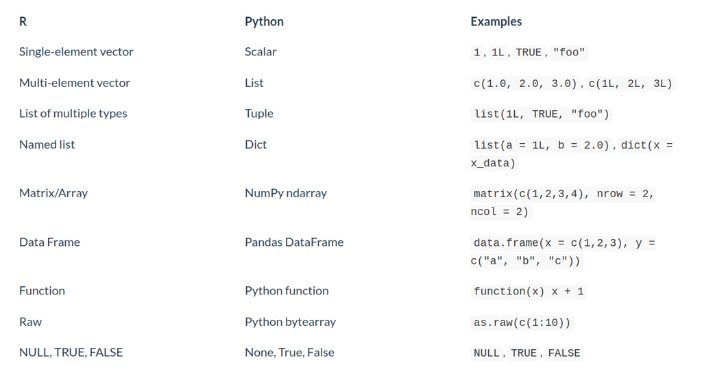

### Reticulate: basics

```r
library(reticulate)

bi <- reticulate::import_builtins()
rd <- reticulate::import("random")

example <- c(1,2,3)
bi$max(example)
# [1] 3
rd$choice(example)
# [1] 2
cat(bi$list(bi$reversed(example)))
# [1] 3 2 1
```

### Reticulate numpy

```r
np <- reticulate::import("numpy")

a <- np$asarray(tuple(list(1,2), list(3, 4)))
b <- np$asarray(list(5,6))
b <- np$reshape(b, newshape = tuple(1L,2L))

np$concatenate(tuple(a, b), axis=0L)
#      [,1] [,2]
# [1,]    1    2
# [2,]    3    4
# [3,]    5    6
```

### Reticulate conversion

```r
np <- reticulate::import("numpy", convert = FALSE)

a <- np$asarray(tuple(list(1,2), list(3, 4)))
b <- np$asarray(list(5,6))
b <- np$reshape(b, newshape = tuple(1L,2L))

np$concatenate(tuple(a, b), axis=0L)
# array([[1., 2.],
#        [3., 4.],
#        [5., 6.]])
```

You can explicitly convert data types:

```r
result <- np$concatenate(tuple(a, b), axis=0L)

py_to_r(result)
#      [,1] [,2]
# [1,]    1    2
# [2,]    3    4
# [3,]    5    6

result_r <- py_to_r(result)
r_to_py(result_r)
# array([[1., 2.],
#        [3., 4.],
#        [5., 6.]])
```

### Reticulate scanpy

```r
library(anndata)
library(reticulate)
sc <- import("scanpy")

adata_path <- "../usecase/data/sc_counts_subset.h5ad"
adata <- anndata::read_h5ad(adata_path)
```

We can preprocess & analyse the data:

```r
sc$pp$filter_cells(adata, min_genes = 200)
sc$pp$filter_genes(adata, min_cells = 3)
sc$pp$pca(adata)
sc$pp$neighbors(adata)
sc$tl$umap(adata)

adata
# AnnData object with n_obs × n_vars = 32727 × 20542
#     obs: 'dose_uM', 'timepoint_hr', 'well', 'row', 'col', 'plate_name', 'cell_id', 'cell_type', 'split', 'donor_id', 'sm_name', 'control', 'SMILES', 'sm_lincs_id', 'library_id', 'leiden_res1', 'group', 'cell_type_orig', 'plate_well_celltype_reannotated', 'cell_count_by_well_celltype', 'cell_count_by_plate_well', 'n_genes'
#     var: 'highly_variable', 'means', 'dispersions', 'dispersions_norm', 'n_cells'
#     uns: 'cell_type_colors', 'celltypist_celltype_colors', 'donor_id_colors', 'hvg', 'leiden_res1_colors', 'log1p', 'neighbors', 'over_clustering', 'rank_genes_groups', 'pca', 'umap'
#     obsm: 'HTO_clr', 'X_pca', 'X_umap', 'protein_counts'
#     varm: 'PCs'
#     obsp: 'connectivities', 'distances'
```

# Disk-based interoperability

Disk-based interoperability is a strategy for achieving interoperability between tools written in different programming languages by **storing intermediate results in standardized, language-agnostic file formats**.

- Upside:
  - Simple, just add reading and witing lines
  - Modular scripts
- Downside:
  - increased disk usage
  - less direct interaction, debugging…

# Important features of interoperable file formats

- Compression
- Sparse matrix support
- Large images
- Lazy chunk loading
- Remote storage

## General single cell file formats of interest for Python and R

| File Format | Python | R | Sparse matrix | Large images | Lazy chunk loading | Remote storage |
| --- | --- | --- | --- | --- | --- | --- |
| RDS | ○ | ● | ○ | ◐ | ○ | ○ |
| Pickle | ● | ○ | ○ | ◐ | ○ | ○ |
| CSV | ● | ● | ○ | ○ | ○ | ○ |
| JSON | ● | ● | ○ | ○ | ○ | ○ |
| TIFF | ● | ● | ○ | ◐ | ● | ◐ |
| [.npy](https://numpy.org/doc/stable/reference/generated/numpy.lib.format.html#module-numpy.lib.format) | ● | ○ | ○ | ● | ○ | ○ |
| [Parquet](https://parquet.apache.org/) | ● | ● | ○ | ○ | ● | ● |
| [Feather](https://arrow.apache.org/docs/python/feather.html) | ● | ● | ● | ○ | ● | ● |
| [Lance](https://github.com/lancedb/lance) | ● | ○ | ● | ○ | ● | ● |
| [HDF5](https://www.hdfgroup.org/) | ● | ● | ○ | ● | ● | ◐ |
| [Zarr](https://zarr.readthedocs.io/en/stable/) | ● | ● | ○ | ● | ● | ● |
| [TileDB](https://tiledb.io/) | ● | ● | ● | ● | ● | ● |

## Specialized single cell file formats of interest for Python and R

| File Format | Python | R | Sparse matrix | Large images | Lazy chunk loading | Remote storage |
| --- | --- | --- | --- | --- | --- | --- |
| [Seurat RDS](https://satijalab.org/seurat/) | ○ | ● | ○ | ◐ | ○ | ○ |
| [Indexed OME-TIFF](http://viv.gehlenborglab.org/#data-preparation) | ● | ● | ○ | ● | ● | ● |
| [h5Seurat](https://mojaveazure.github.io/seurat-disk/index.html) | ● | ● | ○ | ◐ | ● | ◐ |
| [Loom HDF5](https://loompy.org/) | ● | ● | ● | ○ | ● | ◐ |
| [AnnData h5ad](https://anndata.readthedocs.io/en/latest/anndata.zarr.html) | ● | ● | ● | ◐ | ● | ◐ |
| [AnnData Zarr](https://anndata.readthedocs.io/en/latest/anndata.zarr.html) | ● | ● | ● | ◐ | ● | ● |
| [TileDB-SOMA](https://tiledb.com/open-source/life-sciences) | ● | ● | ● | ◐ | ● | ● |
| [TileDB-BioImaging](https://tiledb.com/open-source/life-sciences) | ● | ● | ◐ | ● | ● | ● |
| [SpatialData Zarr](https://spatialdata.scverse.org/en/stable/) | ● | ● | ● | ● | ● | ◐ |

# Disk-based pipelines

Script pipeline:

```bash
#!/bin/bash

bash scripts/1_load_data.sh
python scripts/2_compute_pseudobulk.py
Rscript scripts/3_analysis_de.R
```

Notebook pipeline:

```bash
# Every step can be a new notebook execution with inspectable output
jupyter nbconvert --to notebook --execute my_notebook.ipynb --allow-errors --output-dir outputs/
```

## Just stay in your language and call scripts

```python
import subprocess

subprocess.run("bash scripts/1_load_data.sh", shell=True)
# Alternatively you can run Python code here instead of calling a Python script
subprocess.run("python scripts/2_compute_pseudobulk.py", shell=True)
subprocess.run("Rscript scripts/3_analysis_de.R", shell=True)
```

# Pipelines with different environments

1. interleave with environment (de)activation functions
2. use rvenv
3. use Pixi

## Pixi to manage different environments

```bash
pixi run -e bash scripts/1_load_data.sh
pixi run -e scverse scripts/2_compute_pseudobulk.py
pixi run -e rverse scripts/3_analysis_de.R
```

## Define tasks in Pixi

```bash
...
[feature.bash.tasks]
load_data = "bash book/disk_based/scripts/1_load_data.sh"
...
[feature.scverse.tasks]
compute_pseudobulk = "python book/disk_based/scripts/2_compute_pseudobulk.py"
...
[feature.rverse.tasks]
analysis_de = "Rscript --no-init-file book/disk_based/scripts/3_analysis_de.R"
...
[tasks]
pipeline = { depends-on = ["load_data", "compute_pseudobulk", "analysis_de"] }
```

```bash
pixi run pipeline
```

## Also possible to use containers

```bash
docker pull berombau/polygloty-docker:latest
docker run -it -v $(pwd)/usecase:/app/usecase -v $(pwd)/book:/app/book berombau/polygloty-docker:latest pixi run pipeline
```

Another approach is to use multi-package containers to create custom combinations of packages. - [Multi-Package BioContainers](https://midnighter.github.io/mulled/) - [Seqera Containers](https://seqera.io/containers/)

# Workflows

You can go a long way with a folder of notebooks or scripts and the right tools. But as your project grows more bespoke, it can be worth the effort to use a **workflow framework** like Viash, Nextflow or Snakemake to manage the pipeline for you.

See https://saeyslab.github.io/polygloty/book/workflow_frameworks/